# Prediction Assignment

WC

7/28/2021

## Summary

### The goal of this project is to predict the manner (“classe” in the dataset) in which the 6 partcipants did the exercise, using data from accelerometers on the belt, forearm, arm, and dumbell. A variety of training models are tested, including regression trees, random forest, boosting with trees and linear discriminant analysis models. Among those tested, the random forest model showed the best accuracy, and thus applied to the test data for classificaton.

## Step 1: Data download and preparation

### Download from given urls and select ‘classe’ as response variable, and accelerometer data from belt, forearm, arm and budbell as predictor variables. Then, split the data into training (75%) and testing (25%).

```r
#libraries
library(dplyr)
```

```r
library(tidyr)
library(ggplot2)
library(caret)
library(rattle)
#data download
org_train_data <- read.csv("https://d396qusza40orc.cloudfront.net/predmachlearn/pml-training.csv")
org_test_data <- read.csv("https://d396qusza40orc.cloudfront.net/predmachlearn/pml-testing.csv")

#select accelerometer data only.
set.seed (1234)
train_data <- org_train_data %>% select(starts_with("accel_"))
train_data$classe <- org_train_data$classe
test_data <- org_test_data %>% select(starts_with("accel_"))

#split train_data into training and testing
inTrain <- createDataPartition(y=train_data$classe, p=3/4, list=FALSE)
training <- train_data[inTrain,]
testing <- train_data[-inTrain,]
```

## Step 2: Model building

### Build regression tree, random forest, boosting, and linear model-based prediction models with 5-fold cross validation.

```r
#Predicting with trees
tree_mod <- train(classe ~., method="rpart", trControl=trainControl(method="cv", number=5), data=training)
print(tree_mod)
```

```
## CART
##
## 14718 samples
##    12 predictor
##     5 classes: 'A', 'B', 'C', 'D', 'E'
##
## No pre-processing
## Resampling: Cross-Validated (5 fold)
## Summary of sample sizes: 11774, 11774, 11776, 11774, 11774
## Resampling results across tuning parameters:
##
##   cp          Accuracy   Kappa
##   0.02269059  0.4385767  0.27084454
##   0.03886199  0.3696787  0.14415123
##   0.07585683  0.3045972  0.03097896
##
## Accuracy was used to select the optimal model using the largest value.
## The final value used for the model was cp = 0.02269059.
```

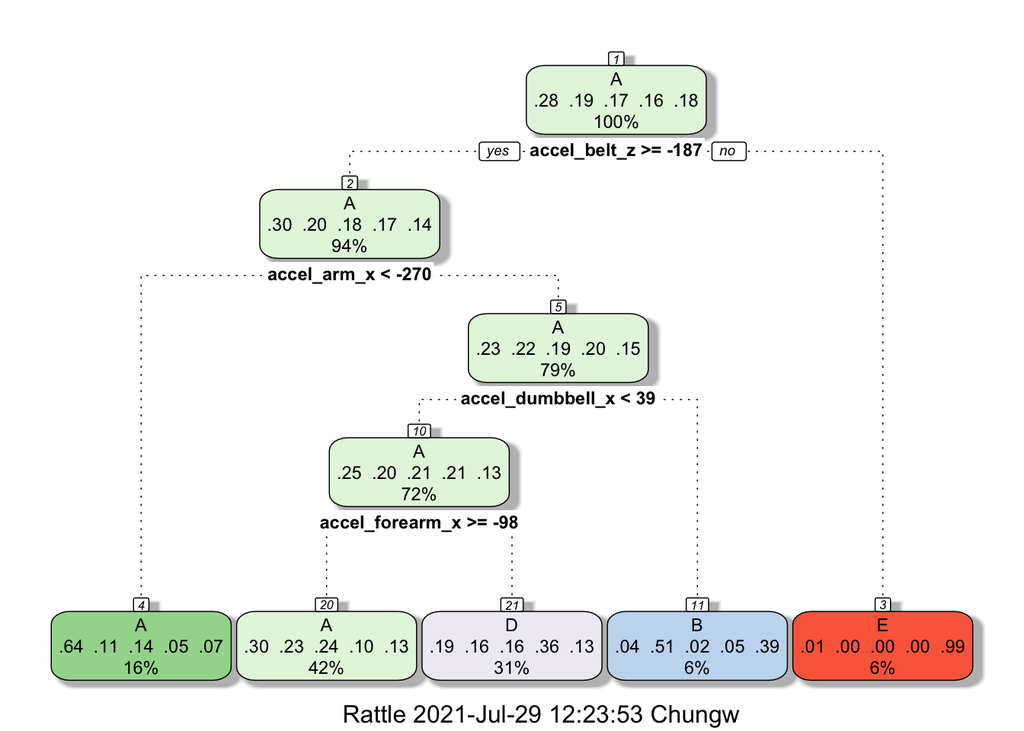

```r
fancyRpartPlot(tree_mod$finalModel)
```

```r
#Random Forests
rf_mod <- train(classe ~., method="rf", trControl=trainControl(method="cv", number=5), data=training)
print(rf_mod)
```

```
## Random Forest
##
## 14718 samples
##    12 predictor
##     5 classes: 'A', 'B', 'C', 'D', 'E'
##
## No pre-processing
## Resampling: Cross-Validated (5 fold)
## Summary of sample sizes: 11775, 11774, 11775, 11775, 11773
## Resampling results across tuning parameters:
##
##   mtry  Accuracy   Kappa
##    2    0.9411606  0.9255588
##    7    0.9338901  0.9163611
##   12    0.9221357  0.9014833
##
## Accuracy was used to select the optimal model using the largest value.
## The final value used for the model was mtry = 2.
```

```r
#Boosting
gbm_mod <- train(classe ~., method="gbm", trControl=trainControl(method="cv", number=5), data=training, verbose=FALSE)
print(gbm_mod)
```

```
## Stochastic Gradient Boosting
##
## 14718 samples
##    12 predictor
##     5 classes: 'A', 'B', 'C', 'D', 'E'
##
## No pre-processing
## Resampling: Cross-Validated (5 fold)
## Summary of sample sizes: 11775, 11775, 11774, 11774, 11774
## Resampling results across tuning parameters:
##
##   interaction.depth  n.trees  Accuracy   Kappa
##   1                   50      0.5494637  0.4199592
##   1                  100      0.5930840  0.4783194
##   1                  150      0.6298416  0.5267060
##   2                   50      0.6590570  0.5638671
##   2                  100      0.7334559  0.6606688
##   2                  150      0.7661373  0.7029398
##   3                   50      0.7279525  0.6535478
##   3                  100      0.7876755  0.7305215
##   3                  150      0.8193375  0.7708700
##
## Tuning parameter 'shrinkage' was held constant at a value of 0.1
##
## Tuning parameter 'n.minobsinnode' was held constant at a value of 10
## Accuracy was used to select the optimal model using the largest value.
## The final values used for the model were n.trees = 150, interaction.depth =
##  3, shrinkage = 0.1 and n.minobsinnode = 10.
```

```r
#Linear discriminant analysis
lda_mod <- train(classe ~., method="lda", trControl=trainControl(method="cv", number=5), data=training)
print(lda_mod)
```

```
## Linear Discriminant Analysis
##
## 14718 samples
##    12 predictor
##     5 classes: 'A', 'B', 'C', 'D', 'E'
##
## No pre-processing
## Resampling: Cross-Validated (5 fold)
## Summary of sample sizes: 11774, 11774, 11775, 11774, 11775
## Resampling results:
##
##   Accuracy   Kappa
##   0.5036016  0.3640248
```

## Step 3: Prediction and Accuracy comparison

### Estimate accuracy of each prediction model against testing data and choose the best model.

### Estimate out of sample error for individual models

```r
#regression trees
tree_pred <- predict(tree_mod, testing)
table(tree_pred)
```

```
## tree_pred
##    A    B    C    D    E
## 2841  318    0 1520  225
```

```r
tree_acc <- confusionMatrix(tree_pred, as.factor(testing$classe))$overall[1]
print(paste("Regression Trees Accuracy:", tree_acc*100))
```

```
## [1] "Regression Trees Accuracy: 41.2724306688418"
```

```r
print(paste("Regression Trees Out of Sample Error:", (1-tree_acc)*100))
```

```
## [1] "Regression Trees Out of Sample Error: 58.7275693311582"
```

```r
#random forest
rf_pred <- predict(rf_mod, testing)
table(rf_pred)
```

```
## rf_pred
##    A    B    C    D    E
## 1411  922  883  786  902
```

```r
rf_acc <- confusionMatrix(rf_pred, as.factor(testing$classe))$overall[1]
print(paste("Random Forest Accuracy:", rf_acc*100))
```

```
## [1] "Random Forest Accuracy: 94.9021207177814"
```

```r
print(paste("Random Forest Out of Sample Error:", (1-rf_acc)*100))
```

```
## [1] "Random Forest Out of Sample Error: 5.0978792822186"
```

```r
#boosting
gbm_pred <- predict(gbm_mod, testing)
table(gbm_pred)
```

```
## gbm_pred
##    A    B    C    D    E
## 1506  890  905  807  796
```

```r
gbm_acc <- confusionMatrix(gbm_pred, as.factor(testing$classe))$overall[1]
print(paste("Boosting with Trees Accuracy:", gbm_acc*100))
```

```
## [1] "Boosting with Trees Accuracy: 82.0962479608483"
```

```r
print(paste("Boosting with Trees Out of Sample Error:", (1-gbm_acc)*100))
```

```
## [1] "Boosting with Trees Out of Sample Error: 17.9037520391517"
```

```r
#linear discriminant analysis
lda_pred <- predict(lda_mod, testing)
table(lda_pred)
```

```
## lda_pred
##    A    B    C    D    E
## 1853  913  641  964  533
```

```r
lda_acc <- confusionMatrix(lda_pred, as.factor(testing$classe))$overall[1]
print(paste("Linear Discriminant Analysis Accuracy:", lda_acc*100))
```

```
## [1] "Linear Discriminant Analysis Accuracy: 50.9176182707993"
```

```r
print(paste("Linear Discriminant Analysis Out of Sample Error:", (1-lda_acc)*100))
```

```
## [1] "Linear Discriminant Analysis Out of Sample Error: 49.0823817292007"
```

## Step 4: Application

### Apply the best model to the new test dataset to predict “classe”.

```r
new_pred <- predict(rf_mod, test_data)
print(new_pred)
```

```
##  [1] B A C A A E D B A A B C B A E E A B B B
## Levels: A B C D E
```